# BIOS967 Final Project

Alora Schneider

2025-12-17

## Introduction

#### Question: What is the relationship between hindfoot length and certain soil type variables (i.e., clay, sand, silt, organic carbon content, and bulk density) for *Ctenomys*?

##### Objectives:

##### 1. Collect soil data for specimen collection localities in Bolivia using R package.

##### 2. Conduct linear regressions on soil variables and hindfoot length and produce scatterplot figures.

##### 3. Produce map figure displaying at least one soil variable spatially in relation to average hindfoot length.

I hypothesize that hind feet will be longer in soils with high bulk density and clay content, and shorter in soils with high sand and silt content.

## Data Collection

Install and load necessary packages:

geodata: global soils data terra: working with SpatRaster data formats readr: downloading csv files ggplot2, ggpubr, sf: plotting

**(Note: Remove comments around code chunk when running, this was necessary to run without errors due to the geodata outage)**

#```{r data, message = FALSE, warning = FALSE, echo = TRUE} dataset = utils::read.csv(“tuco_tuco_soils.csv”) #Load in incomplete data set with latitudes/longitudes for each specimen collection location #truncate into lat_long data frame lat_long = dataset[, 5:6]

#transform into a point spatial vector so extract() knows what to do with it lat_long <- terra::vect(lat_long, geom = c(“lon”, “lat”), crs = “epsg:4326”, keepgeom=FALSE)

#extract spatial rasters with each of five soil variables at 30cm depth across entire globe bulk_density = geodata::soil_world(var = “bdod”, depth = 30, stat = “mean”, VSI = TRUE) #extract soil data values from specific lattitudes and longitudes bulk_density_df = terra::extract(bulk_density, lat_long) #repeat for remaining 4 variables clay = geodata::soil_world(var = “clay”, depth = 30, stat = “mean”) clay_df = terra::extract(clay, lat_long) sand = geodata::soil_world(var = “sand”, depth = 30, stat = “mean”) sand_df = terra::extract(sand, lat_long) silt = geodata::soil_world(var = “silt”, depth = 30, stat = “mean”) silt_df = terra::extract(silt, lat_long) soil_org_carbon = geodata::soil_world(var = “soc”, depth = 30, stat = “mean”) soc_df = terra::extract(org_carb_stock, lat_long)

#add soil variables into columns from initial dataset dataset$Bulk_soil_density = bulk_density_df[, 2] dataset$Sand_content = sand_df[, 2] dataset$Clay_content = clay_df[, 2] dataset$Silt_content = silt_df[, 2] dataset$Organic_content = soc_df[, 2]

#load in incomplete dataset of individual specimen data tuco_data = read.csv(“BIOS967_FINAL_DATASET.csv”) tuco_data = tuco_data[, 1:6] #merge specimen data and lat-long soil data data = merge(dataset, tuco_data) #remove row that didn’t work (NA value) data = na.omit(data) data = data[, c(1, 5:16)] #Write complete dataset as csv and save to files write.csv(data, file = “BIOS967_COMPLETE_DATA.csv”) #```

## Linear Regression Statistics

Made linear models for each variable and checked statistics

```r
##BULK DENSITY VS HFL
data = read.csv("BIOS967_COMPLETE_DATA.csv")
bd_vs_hfl = lm(Bulk_soil_density~Hind_foot_length, data = data)
summary(bd_vs_hfl)
```

```
##
## Call:
## lm(formula = Bulk_soil_density ~ Hind_foot_length, data = data)
##
## Residuals:
##       Min        1Q    Median        3Q       Max
## -0.193052 -0.029628 -0.007683  0.032551  0.132551
##
## Coefficients:
##                  Estimate Std. Error t value Pr(>|t|)
## (Intercept)      1.157722   0.027376  42.290  < 2e-16 ***
## Hind_foot_length 0.003658   0.000688   5.316 1.98e-07 ***
## ---
## Signif. codes:  0 '***' 0.001 '**' 0.01 '*' 0.05 '.' 0.1 ' ' 1
##
## Residual standard error: 0.0684 on 322 degrees of freedom
## Multiple R-squared:  0.08069,    Adjusted R-squared:  0.07784
## F-statistic: 28.26 on 1 and 322 DF,  p-value: 1.983e-07
```

```r
#slope 0.003658, p value <0.001, R-squared = 0.07784
#slight positive statistically significant relationship
```

```r
##CLAY VS HFL
c_vs_hfl = lm(Clay_content~Hind_foot_length, data = data)
summary(c_vs_hfl)
```

```
##
## Call:
## lm(formula = Clay_content ~ Hind_foot_length, data = data)
##
## Residuals:
##      Min       1Q   Median       3Q      Max
## -10.9273  -2.5688  -0.0249   3.2507   8.8848
##
## Coefficients:
##                  Estimate Std. Error t value Pr(>|t|)
## (Intercept)      43.46878    1.57663  27.571   <2e-16 ***
## Hind_foot_length -0.36341    0.03962  -9.172   <2e-16 ***
## ---
## Signif. codes:  0 '***' 0.001 '**' 0.01 '*' 0.05 '.' 0.1 ' ' 1
##
## Residual standard error: 3.94 on 322 degrees of freedom
## Multiple R-squared:  0.2071, Adjusted R-squared:  0.2047
## F-statistic: 84.12 on 1 and 322 DF,  p-value: < 2.2e-16
```

```r
#slope -0.36341, p value <0.001, R-squared = 0.2047
#slight negative statistically significant relationship
```

```r
##SAND VS HFL
sa_vs_hfl = lm(Sand_content~Hind_foot_length, data = data)
summary(sa_vs_hfl)
```

```
##
## Call:
## lm(formula = Sand_content ~ Hind_foot_length, data = data)
##
## Residuals:
##      Min       1Q   Median       3Q      Max
## -18.4538  -3.8221  -0.1448   3.9521  13.1277
##
## Coefficients:
##                  Estimate Std. Error t value Pr(>|t|)
## (Intercept)      29.90881    2.40790  12.421  < 2e-16 ***
## Hind_foot_length  0.44242    0.06051   7.311 2.11e-12 ***
## ---
## Signif. codes:  0 '***' 0.001 '**' 0.01 '*' 0.05 '.' 0.1 ' ' 1
##
## Residual standard error: 6.017 on 322 degrees of freedom
## Multiple R-squared:  0.1424, Adjusted R-squared:  0.1397
## F-statistic: 53.45 on 1 and 322 DF,  p-value: 2.113e-12
```

```r
#slope 0.44242, p value <0.001, R-squared = 0.1397
#positive statistically significant relationship
```

```r
#SILT VS HFL
si_vs_hfl = lm(Silt_content~Hind_foot_length, data = data)
summary(si_vs_hfl)
```

```
##
## Call:
## lm(formula = Silt_content ~ Hind_foot_length, data = data)
##
## Residuals:
##     Min      1Q  Median      3Q     Max
## -9.0716 -3.0691 -0.1602  2.8555 14.4388
##
## Coefficients:
##                  Estimate Std. Error t value Pr(>|t|)
## (Intercept)      26.25884    1.91678  13.699   <2e-16 ***
## Hind_foot_length -0.07291    0.04817  -1.514    0.131
## ---
## Signif. codes:  0 '***' 0.001 '**' 0.01 '*' 0.05 '.' 0.1 ' ' 1
##
## Residual standard error: 4.789 on 322 degrees of freedom
## Multiple R-squared:  0.007064,   Adjusted R-squared:  0.00398
## F-statistic: 2.291 on 1 and 322 DF,  p-value: 0.1311
```

```r
#slope -0.07291, p value 0.1311, R-squared = 0.00398
#slightly negative insignificant relationship
```

```r
#ORGANIC CARBON VS HFL
oc_vs_hfl = lm(Organic_content~Hind_foot_length, data = data)
summary(oc_vs_hfl)
```

```
##
## Call:
## lm(formula = Organic_content ~ Hind_foot_length, data = data)
##
## Residuals:
##     Min      1Q  Median      3Q     Max
## -8.0277 -2.9451  0.0698  2.7868  9.5495
##
## Coefficients:
##                  Estimate Std. Error t value Pr(>|t|)
## (Intercept)      21.71994    1.65726  13.106  < 2e-16 ***
## Hind_foot_length -0.17974    0.04165  -4.316 2.12e-05 ***
## ---
## Signif. codes:  0 '***' 0.001 '**' 0.01 '*' 0.05 '.' 0.1 ' ' 1
##
## Residual standard error: 4.141 on 322 degrees of freedom
## Multiple R-squared:  0.05468,    Adjusted R-squared:  0.05174
## F-statistic: 18.62 on 1 and 322 DF,  p-value: 2.12e-05
```

```r
#slope -0.17974, p value <0.001, R-squared = 0.05174
#slightly negative statistically significant relationship
```

## Linear Regression Figures

Made figure objects for each with scatterplot, trendline and statistics. Then combined into single figure using ggpubr

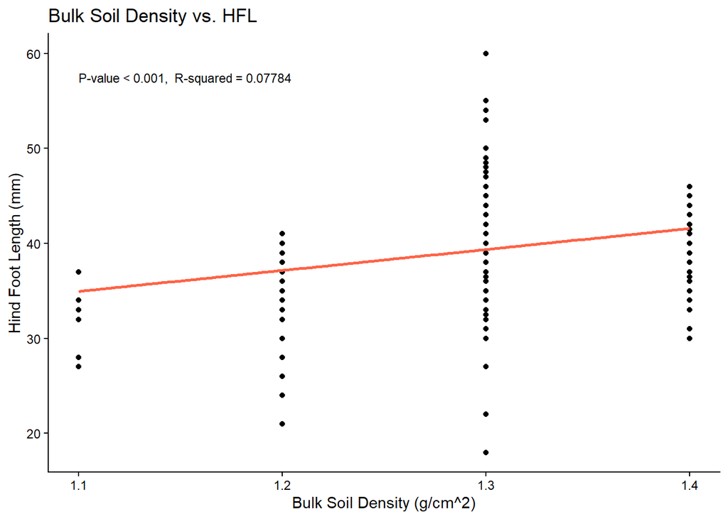

```r
##Fig 1 - Bulk density vs. HFL
bd_stat = paste0("P-value < 0.001, ", " ",
                 "R-squared = 0.07784")
fig1 = ggplot(data = data, mapping = aes(y = Hind_foot_length, x = Bulk_soil_density)) +
  geom_point() +
  geom_smooth(method="lm", se = FALSE, color = "tomato") +
  xlab("Bulk Soil Density (g/cm^2)") +
  ylab("Hind Foot Length (mm)") +
  theme_classic() +
  ggtitle("Bulk Soil Density vs. HFL") +
  annotate("text", x = 1.1, y = 58,
           label = bd_stat, hjust = 0, vjust = 1, size = 3)
print(fig1)
```

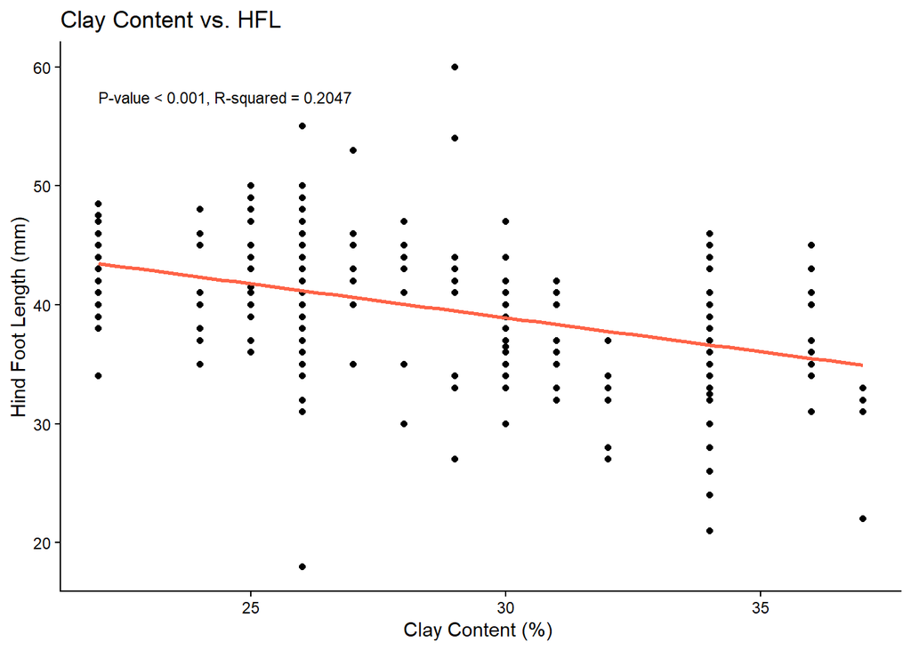

```r
##Fig 2 - Clay content vs. HFL
cl_stat = paste0("P-value < 0.001,", " ",
                 "R-squared = 0.2047")
fig2 = ggplot(data = data, mapping = aes(y = Hind_foot_length, x = Clay_content)) +
  geom_point() +
  geom_smooth(method = "lm", se = FALSE, color = "tomato") +
  xlab("Clay Content (%) ") +
  ylab("Hind Foot Length (mm)") +
  theme_classic()+
  theme_classic() +
  ggtitle("Clay Content vs. HFL") +
  annotate("text", x = 22, y = 58,
           label = cl_stat, hjust = 0, vjust = 1, size = 3)
print(fig2)
```

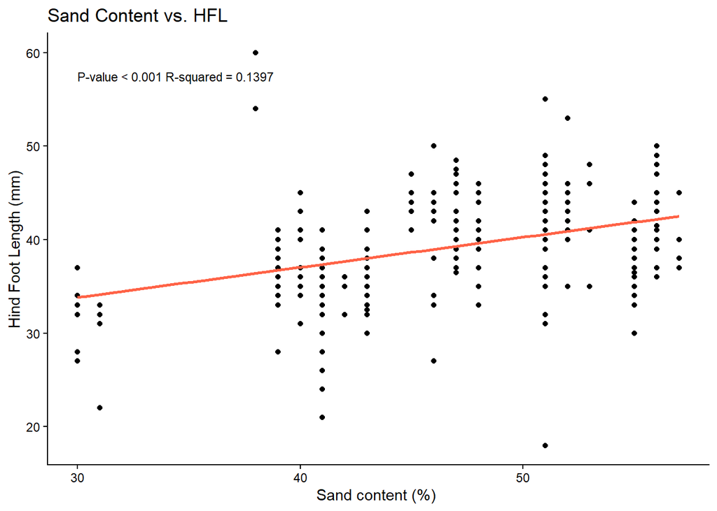

```r
##Fig 3 - Sand content vs. HFL
sd_stats = paste0("P-value < 0.001", " ",
                  "R-squared = 0.1397")
fig3 = ggplot(data = data, mapping = aes(y = Hind_foot_length, x = Sand_content)) +
  geom_point() +
  geom_smooth(method = "lm", se = FALSE, color = "tomato") +
  xlab("Sand content (%) ") +
  ylab("Hind Foot Length (mm)") +
  theme_classic()+
  ggtitle("Sand Content vs. HFL") +
  annotate("text", x = 30, y = 58,
           label = sd_stats, hjust = 0, vjust = 1, size = 3)
print(fig3)
```

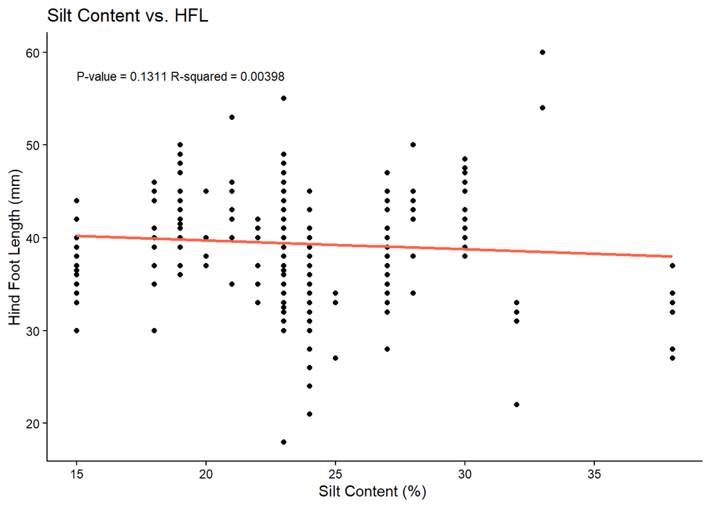

```r
##Fig 4 - Silt content vs. HFL
si_stat = paste0("P-value = 0.1311", " ",
                  "R-squared = 0.00398")
fig4 = ggplot(data = data, mapping = aes(y = Hind_foot_length, x = Silt_content)) +
  geom_point() +
  geom_smooth(method = "lm", se = FALSE, color = "tomato") +
  xlab("Silt Content (%) ") +
  ylab("Hind Foot Length (mm)") +
  theme_classic()+
  ggtitle("Silt Content vs. HFL") +
  annotate("text", x = 15, y = 58,
           label = si_stat, hjust = 0, vjust = 1, size = 3)
print(fig4)
```

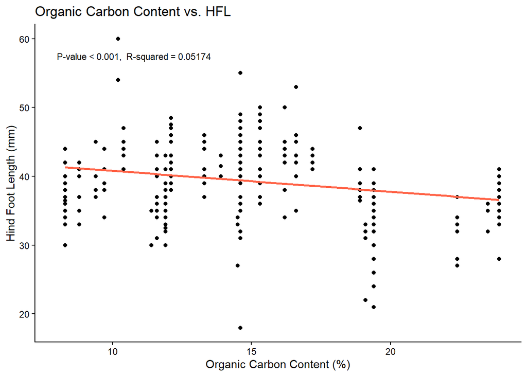

```r
##Fig 5 - Organic carbon content vs. HFL
oc_stat = paste0("P-value < 0.001, ", " ",
                 "R-squared = 0.05174")
fig5 = ggplot(data = data, mapping = aes(y = Hind_foot_length, x = Organic_content)) +
  geom_point() +
  geom_smooth(method = "lm", se = FALSE, color = "tomato") +
  xlab("Organic Carbon Content (%)") +
  ylab("Hind Foot Length (mm)") +
  theme_classic() +
  ggtitle("Organic Carbon Content vs. HFL") +
  annotate("text", x = 8, y = 58,
           label = oc_stat, hjust = 0, vjust = 1, size = 3)
print(fig5)
```

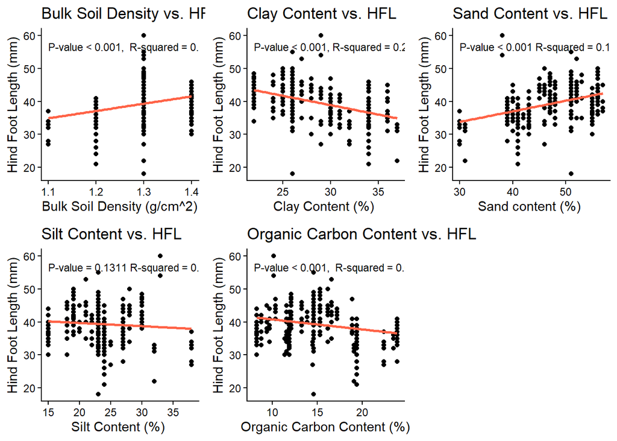

```r
figure = ggpubr::ggarrange(fig1, fig2, fig3, fig4, fig5, ncol = 3, nrow = 2)
#save completed figure
ggsave("bios967_fig1.png", width = 10, height = 10)
print(figure)
```

## Mapping

Since clay was the most significant statistically, I decided to use that variable to create a map showing HFL and soil type spatially.

[figure not shown]

```r
##Fig 6 - Clay content figure
#bin the hind foot lengths by average over one location, merge with original dataset
average_by_latlong = aggregate(Hind_foot_length~lat, data = data, FUN = mean)
colnames(average_by_latlong)[2] = "av_HFL"
data_av = merge(data, average_by_latlong)

#load in bolivia shape file
bolivia = st_read("bo.shp")
#create plot
map = ggplot(data = bolivia) +
  geom_sf(col = "black") +
  geom_point(data = data_av, mapping = aes(x = lon, y = lat, size = av_HFL, colour = Clay_content)) +
  scale_color_binned(palette = c("darkblue", "slateblue","orange2","tomato")) +
  theme_classic(base_size = 12) +
  ggtitle("Average HFL vs. Clay Content") +
  xlab("Lattitude") +
  ylab("Longitude") +
  labs(color = "Clay Content (%)", size = "Average Hind Foot Length (mm)")
#save plot
ggsave("clay_content_map.png", width = 8, height = 7)
print(map)
```

## References

Gardner, S.L. 1991. Phyletic coevolution between subterranean rodents of the genus Ctenomys (Rodentia: Hystricognathi) and nematodes of the genus Paraspidodera (Heterakoidea: Aspidoderidae) in the Neotropics: Temporal and evolutionary implications. Zoological Journal of the Linnean Society of London 102: 169-201.

Gardner, S.L., Salazar-Bravo, J., & Cook, J.A. (2014). New species of Ctenomys Blainville 1826 (Rodentia: Ctenomyidae) from the lowlands and central valleys of Bolivia. Special Publication, Museum of Texas Tech University 62: 1-34.

Gardner, S. L., Botero-Cañola, S., Aliaga-Rossel, E., Dursahinhan, A.T., & Salazar-Bravo, J. (2021). Conservation status and natural history of Ctenomys, tuco-tucos in Bolivia. Therya, 12(1), 15-36.

Hengl, T., Mendes de Jesus, J., Heuvelink, G.B., Ruiperez Gonzalez, M., Kilibarda, M., Blagotić, A., … & Kempen, B. (2017). SoilGrids250m: Global gridded soil information based on machine learning. PLoS one, 12(2), e0169748.

Justo, E.R., De Santis, L. J., & Kin, M. S. (2003). Ctenomys talarum. Mammalian species, 730, 1-5.

Lacey, E. A., Amaya, J. P., Irian, C. G., Carrizo, P. G., O’Brien, S. L., & Ojeda, A. A. (2022). Variable social organization among tuco-tucos (genus Ctenomys) in the opimus clade. Journal of Mammalogy, 103(4), 979-992.

Poggio L., de Sousa L.M., Batjes N.H., Heuvelink G.B.M., Kempen B., Ribeiro E., Rossiter D. (2021) SoilGrids 2.0: producing soil information for the globe with quantified spatial uncertainty. Soil, 7: 217-240, 2021. doi:10.5194/soil-7-217-2021

Rosi, M. I., Cona, M. I., Videla, F., Puig, S., Monge, S. A., & Roig, V. G. (2003). Diet selection by the fossorial rodent Ctenomys mendocinus inhabiting an environment with low food availability (Mendoza, Argentina). Studies on Neotropical Fauna and Environment, 38(3), 159-166.

Rosi, M.I., Cona, M.I., Roig, V.G., Massarini, A.I., & Verzi, D.H. (2005). Ctenomys mendocinus. Mammalian Species, 777, 1-6.

Vassallo, A.I. (1998). Functional morphology, comparative behaviour, and adaptation in two sympatric subterranean rodents genus Ctenomys (Caviomorpha: Octodontidae). Journal of Zoology, 244(3), 415-427.

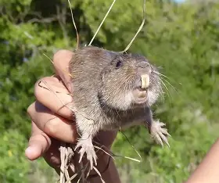

Thank you!